# Analysis of Urban Ministries of Durham Data

Joseph Foster

9/25/2019

### Motivation of Overview

Given one of the primary methods through which UMD is helping to end homelessness is food, I aim to assess how well the organization has distributed food in the past, and what factors may have influenced that distribution.

### Report

I first looked at how much food is distributed annually from 2006 to current date. What I found was the total annual food provide has increased over the last 5 years, and has been trending upward since 2006.

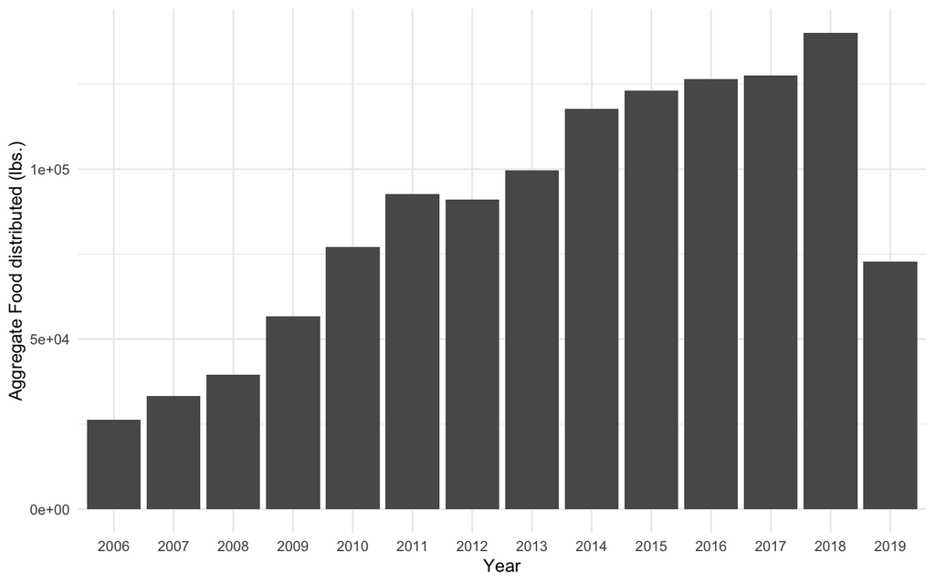

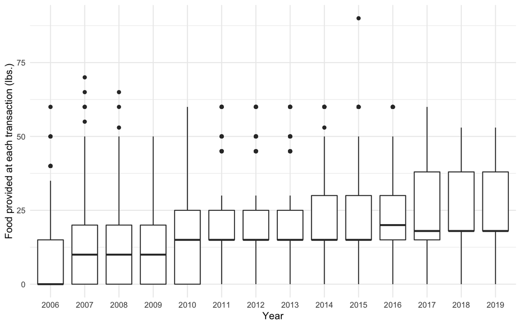

To understand if paying a bill impacts the amount of food received per interaction, I looked at the amount of food received per interaction on an annual basis for individuals who reported paying a bill and those who did not. Over the past 13 years only two of the years showed a significant difference in the amount of food received when the client also reported paying a bill. However, these data shouldn’t be over interpreted as there were only 127 interactions where a bill was reported as paid, while there were over 65,000 interactions with no mention of paying bills.

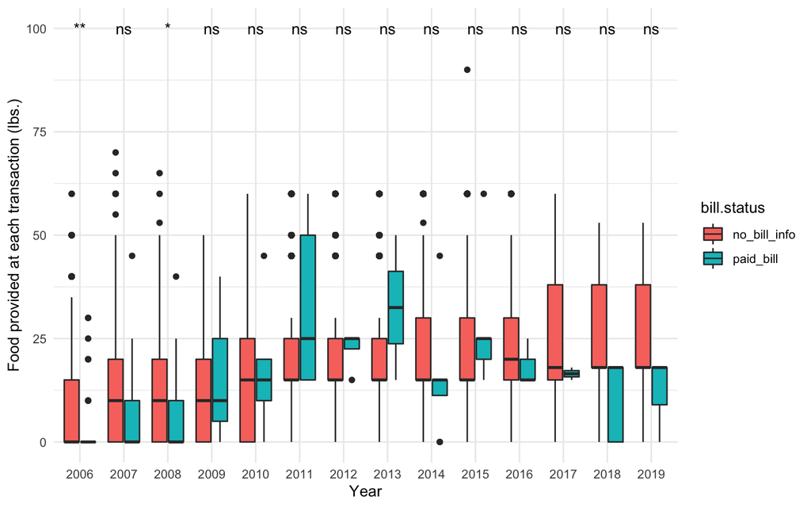

In summary, over the past decade UMD has been able to increase the total amount of food reaching its clients, while also increasing the average amount of food given per interaction. Although the data for clients paying bills was sparse, there is some evidence to suggest that reporting payment of bills doesn’t have an impact on the average amount of food clients receive at a given interaction. Given, one of the central tenants of UMD is to provide food to the community these preliminary results are encouraging.

### Notes on future data collection

1. While cleaning the data I noticed there were lines dating back to 1931, which predates the existence of UMD. There are also records listing future dates. It would be helpful to understand if these data are erroneous or if they have some other type of significance.
2. While looking into the total amount of food provided each year I came across a record (client #: 12943) that had received 450121 pounds of food during one interaction. I assume that this was a data entry error. It would be helpful to know what the upper and lower limits are on the amount of food distributed at any one time.
3. The analyses reported here focused on the year range 2006-2019 because the data before 2006 was sparse in comparison. Are there additional records from earlier years?